# CARS STOCK ANALYSIS

**ANALYSE TWO CAR COMPANYS MOST FAMOUS IN USA(FORD) AND EUROPE(VW) FOR 2020**

```python
import numpy as np
import pandas as pd
import matplotlib.pyplot as plt
%matplotlib inline
import seaborn as sns
```

```python
import pandas_datareader
import datetime
```

```python
import pandas_datareader.data as web
```

```python
start = datetime.datetime(2020, 1, 1)
end = datetime.datetime(2021, 1, 1)
FORD= web.DataReader('FORD','yahoo', start, end)
VWAGY= web.DataReader('VWAGY','yahoo', start, end)
```

**Adj Close**

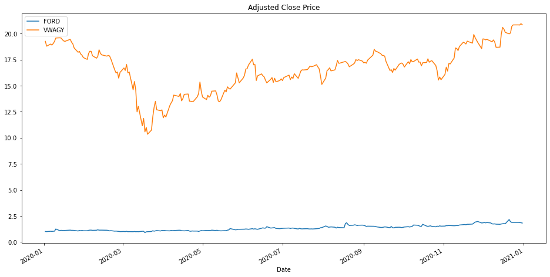

```python
FORD['Adj Close'].plot(label='FORD',figsize=(16,8),title='Adjusted Close Price',legend=True)
VWAGY['Adj Close'].plot(label='VWAGY',legend=True)
```

**Volume**

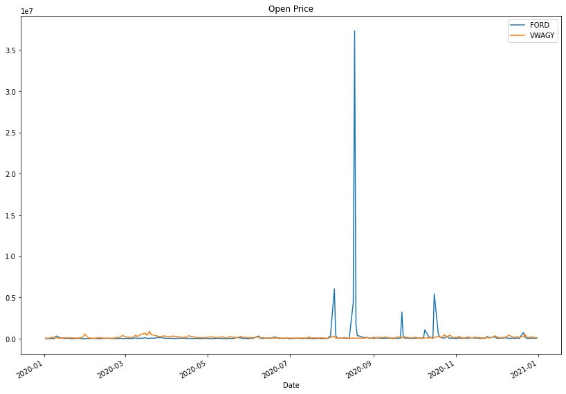

```python
FORD['Volume'].plot(label='FORD',figsize=(14,10),title='Open Price',legend=True)
VWAGY['Volume'].plot(label='VWAGY',legend=True)
```

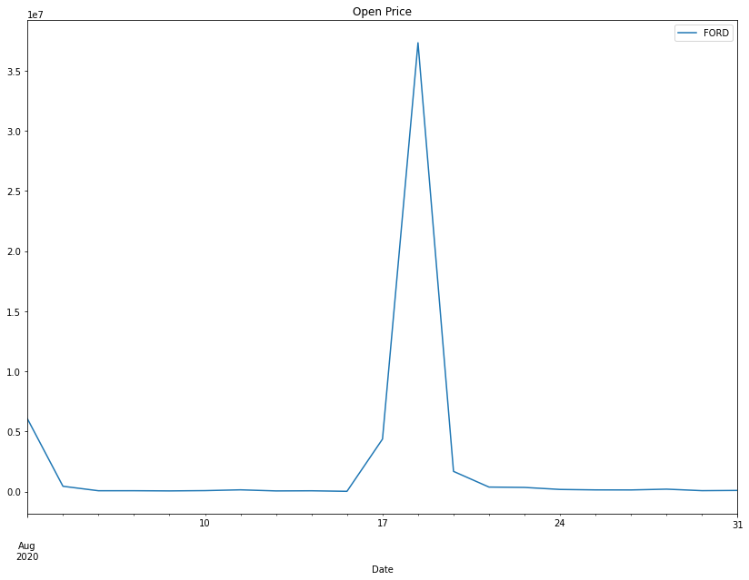

```python
FORD['Volume'].argmax()

FORD.iloc[151]

FORD['Volume']['2020-08'].plot(label='FORD',figsize=(14,10),title='Open Price',legend=True)
```

**Reason is the news about FORD for that period of time:**

NEW YORK, Aug. 17, 2020 – All-new versions of the Ford F-150, part of Ford F-Series, America’s most popular truck for 43 years and most popular vehicle for 38 years, and the much-anticipated Ford Bronco rugged SUV debut in New York City today, in conjunction with the company ringing the bell to open trading day on Wall Street.</b>

**MARKET CAP -This still isn't the actual Market Cap, its just a visual representation of the total amount of money being traded around using the time series.**

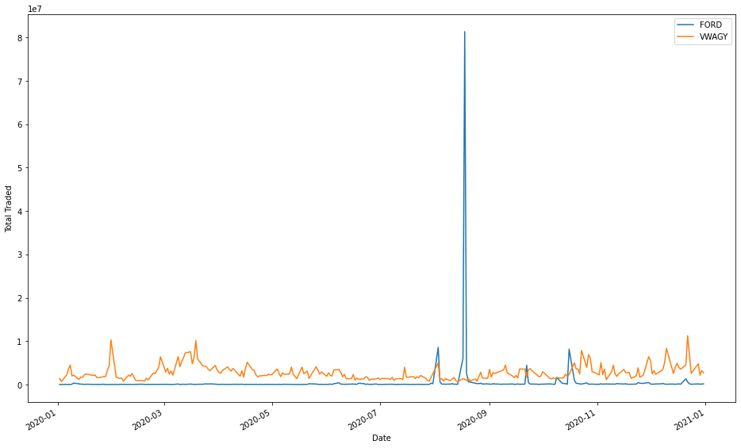

```python
FORD['Total Traded'] = FORD['Open']*FORD['Volume']
VWAGY['Total Traded'] = VWAGY['Open']*VWAGY['Volume']

FORD['Total Traded'].plot(label='FORD',figsize=(16,10))
VWAGY['Total Traded'].plot(label='VWAGY')

plt.legend()
plt.ylabel('Total Traded')
```

**We can see that even though Ford has an a big spike of total trading money at certain period, VW also had 'steady' money traded overall.**

**DAILY RETURNS**

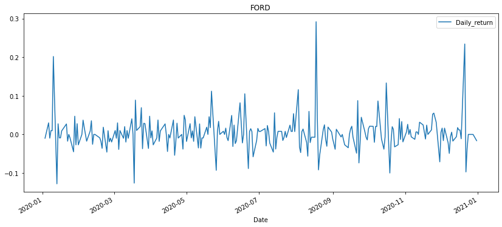

```python
FORD['Daily_return']=FORD['Adj Close'].pct_change()
FORD['Daily_return'].plot(figsize=(14,6),legend=True,title='FORD')
```

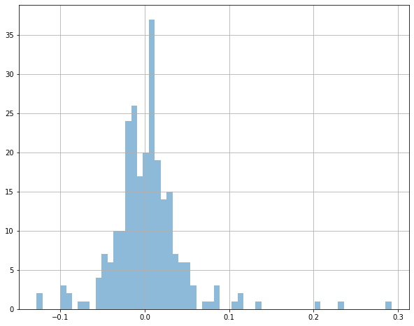

```python
FORD['Daily_return'].hist(bins=60,label='FORD',figsize=(10,8),alpha=0.5)
```

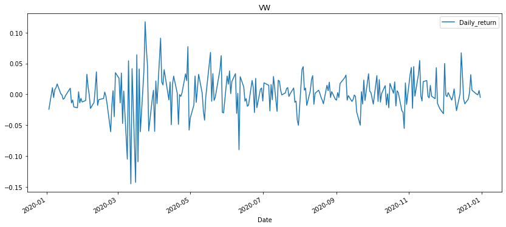

```python
VWAGY['Daily_return']=VWAGY['Adj Close'].pct_change()
VWAGY['Daily_return'].plot(figsize=(14,6),legend=True,title='VW')
```

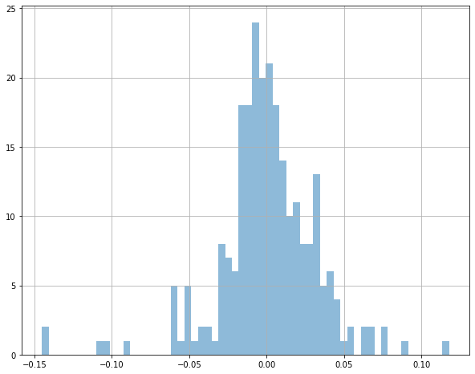

```python
VWAGY['Daily_return'].hist(bins=60,label='VW',figsize=(10,8),alpha=0.5)
```

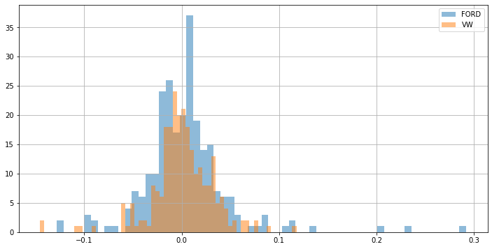

```python
FORD['Daily_return'].hist(bins=60,label='FORD',figsize=(12,6),alpha=0.5)
VWAGY['Daily_return'].hist(bins=60,label='VW',alpha=0.5)
plt.legend()
```

**We can see ups and downs on the both car company plots. Longer period of loss in VW, however good periods of gain during the year. FORD seems more solid in a way of gain. Looking on the last plot where both hist. are on top of each other-FORD seems to overpower the Daily returns overall.**

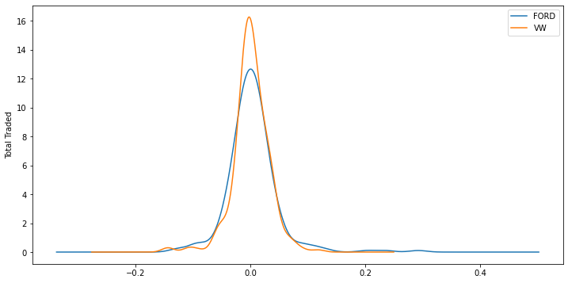

```python
FORD['Daily_return'].plot(kind='kde',label='FORD',figsize=(12,6))
VWAGY['Daily_return'].plot(kind='kde',label='VW')
plt.legend()
plt.ylabel('Total Traded')
```

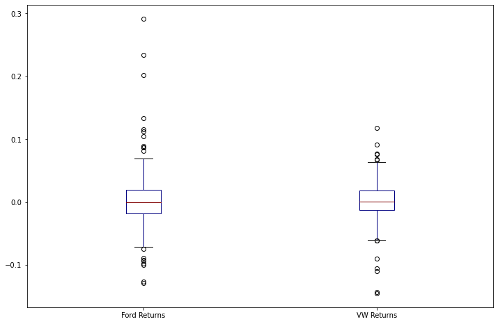

```python
box_df = pd.concat([FORD['Daily_return'],VWAGY['Daily_return']],axis=1)
box_df.columns = ['Ford Returns','VW Returns']
box_df.plot(kind='box',figsize=(12,8),colormap='jet')
```

**FROM KDE(Kernel density estimation) and the Box plot I can see that FORD profited more. However FORD shows bigger loss value throughout the year than VW.**

**CUMULATIVE RETURN**

While daily returns are useful, it doesn't give the investor a immediate insight into the gains he had made till date. Especially if the stock is very volatile. Cumulative return is computed relative to the day investment is made. If cumulative return is above one, you are making profits else you are in loss.</b>

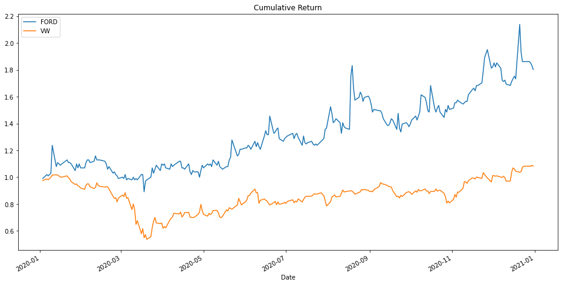

```python
FORD['Cumulative Return'] = (1 + FORD['Daily_return']).cumprod()
VWAGY['Cumulative Return'] = (1 + VWAGY['Daily_return']).cumprod()

FORD['Cumulative Return'].plot(label='FORD',figsize=(16,8),title='Cumulative Return')
VWAGY['Cumulative Return'].plot(label='VW')
plt.legend()
```

**Showed the highest return for a $1 invested.**

This plot show that FORD is way more attractive as the profit continues to grow after may 2020. Where the profit for VW plummet at the beginning of the year and slowly recovered to make small profits at the end of 2020 and beginning of 2021. </b>

**MONTHLY ANALYSIS**

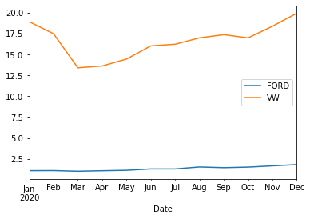

```python
FORD['Adj Close'].resample('M').mean().plot(label='FORD')
VWAGY['Adj Close'].resample('M').mean().plot(label='VW')
plt.legend()
```

**FROM this monthly analyses plot we see that FORD had small steady increase throughout the year.**

VW at the first 3 months had bigger drop, after the month of March gain some momentum and move up for the remaining of the year.</b>

**MOVING AVERAGES**

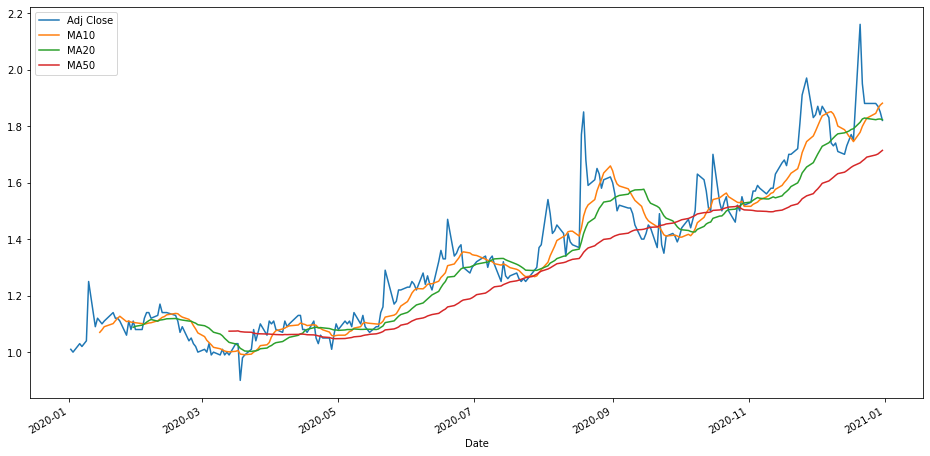

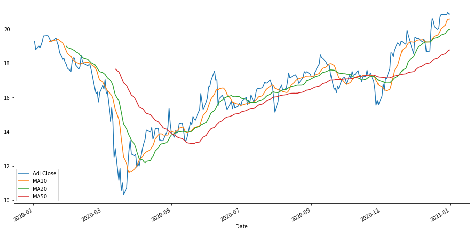

```python
FORD['MA10'] = FORD['Adj Close'].rolling(10).mean()
FORD['MA20'] = FORD['Adj Close'].rolling(20).mean()
FORD['MA50'] = FORD['Adj Close'].rolling(50).mean()
FORD[['Adj Close','MA10','MA20','MA50']].plot(label='FORD',figsize=(16,8))

VWAGY['MA10'] = VWAGY['Adj Close'].rolling(10).mean()
VWAGY['MA20'] = VWAGY['Adj Close'].rolling(20).mean()
VWAGY['MA50'] = VWAGY['Adj Close'].rolling(50).mean()
VWAGY[['Adj Close','MA10','MA20','MA50']].plot(label='VW',figsize=(16,8))
```

**Really beneficial to see the trend moving for the 10,20 and 50 days period**

**CORROLETION BETWEEN THE TWO COMPANY DATA**

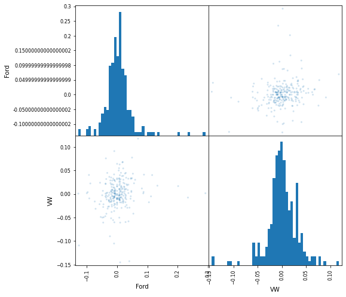

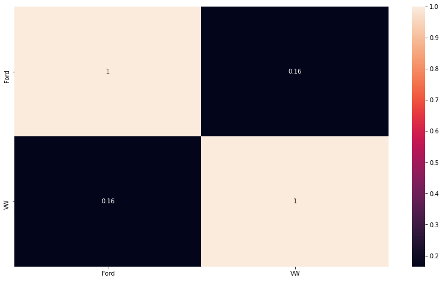

```python
daily_r_corr=pd.concat([FORD['Daily_return'],VWAGY['Daily_return']],axis=1)

daily_r_corr

daily_r_corr.columns.values[[0, 1]] = ['Ford', 'VW']

daily_r_corr

pd.plotting.scatter_matrix(daily_r_corr,figsize=(8,8),alpha=0.2,hist_kwds={'bins':50});

daily_r_corr.plot(kind='scatter',x='Ford',y='VW',alpha=0.4,figsize=(14,8))

sns.heatmap(daily_r_corr.corr(),annot=True)
```

**PLOTTING THE DAILY RETURNS FIRST PLOT - SCATTER MATRIX AND HEATMAP PLOT BOTH SHOW 0.16 CORROLETION-NO RELATIONSHIP. EXAMPLE BELLOW WE CAN SEE SOME KIND OF CORROLETION BETWEEN CLOSE VALUES OF THE BOTH COMPANYS WHICH IS SHOW BETTER CORROLETION APPR:0.55**

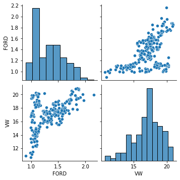

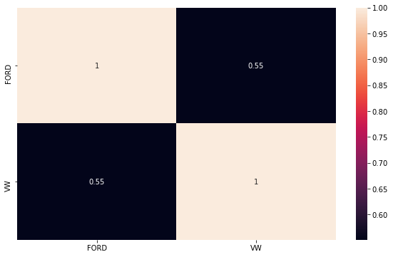

```python
close=pd.DataFrame()

close['FORD']=FORD['Close']
close['VW']=VWAGY['Close']


sns.pairplot(data=close)

close.plot(kind='scatter',x='FORD',y='VW',alpha=0.4,figsize=(10,6))

sns.heatmap(close.corr(),annot=True)
```

```python
from pandas_datareader.data import DataReader
```

**RISK ANALYSES**

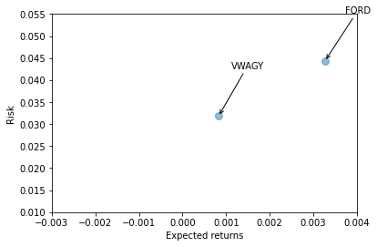

```python
car_list=['FORD','VWAGY']
closing_df=DataReader(car_list,'yahoo',start,end)['Adj Close']

tech_rets=closing_df.pct_change()

tech_rets

rets = tech_rets

area = np.pi*20

plt.scatter(rets.mean(),rets.std(),alpha = 0.5,s =area)

plt.ylim([0.01,0.055])
plt.xlim([-0.003,0.004])

plt.xlabel('Expected returns')
plt.ylabel('Risk')

for label, x, y in zip(rets.columns,rets.mean(),rets.std()):
    plt.annotate(
        label,
        xy = (x, y), xytext = (50, 50),
        textcoords = 'offset points', ha = 'right', va = 'bottom',arrowprops=dict(arrowstyle="->",
                            connectionstyle="arc3"))
```

**We can see higher risk for FORD, however also higher Expected returns. Subsequently- Lower risk and lower Expected returns for VW**

**FORD-DISPLOT**

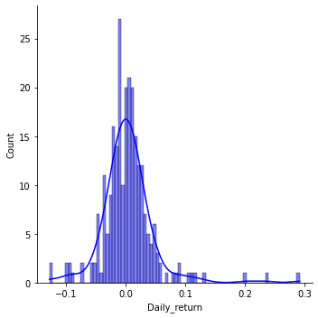

```python
ax=sns.displot(data=FORD['Daily_return'],kde=True,bins=80,color='blue')
```

**VW-DISPLOT**

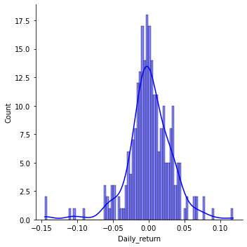

```python
ax=sns.displot(data=VWAGY['Daily_return'],kde=True,bins=80,color='blue')
```

**Shows the distribution of the Daily Returns from FORD and VW**

```python
rets['FORD'].quantile(0.05)
```

```
-0.05115631034479798
```

**FORD - The 0.05 empirical quantile of daily returns is at -0.051. That means that with 95% confidence,**

Our worst daily loss will not exceed 5.1%. If we have a 1 million dollar investment, our one-day 5% VaR is 0.051 * 1,000,000 = $51,000.</b>

```python
rets['VWAGY'].quantile(0.05)
```

```
-0.05007525665936031
```

**VW - The 0.05 empirical quantile of daily returns is at -0.050. That means that with 95% confidence, Our worst daily loss will not exceed 5.0%. If we have a 1 million dollar investment, our one-day 5% VaR is 0.050 * 1,000,000 = $50,000.**

```python
FORD.head()
```

| Date | High | Low | Open | Close | Volume | Adj Close | Total Traded | Daily_return | Cumulative Return | MA10 | MA20 | MA50 |
| --- | --- | --- | --- | --- | --- | --- | --- | --- | --- | --- | --- | --- |
| 2020-01-02 | 1.03 | 1.00 | 1.00 | 1.01 | 8700 | 1.01 | 8700.000000 | NaN | NaN | NaN | NaN | NaN |
| 2020-01-03 | 1.05 | 0.99 | 0.99 | 1.00 | 6400 | 1.00 | 6336.000061 | -0.009901 | 0.990099 | NaN | NaN | NaN |
| 2020-01-06 | 1.05 | 0.99 | 0.99 | 1.03 | 16700 | 1.03 | 16533.000159 | 0.030000 | 1.019802 | NaN | NaN | NaN |
| 2020-01-07 | 1.05 | 1.00 | 1.04 | 1.02 | 38800 | 1.02 | 40351.998520 | -0.009709 | 1.009901 | NaN | NaN | NaN |
| 2020-01-08 | 1.03 | 1.00 | 1.03 | 1.03 | 3700 | 1.03 | 3810.999894 | 0.009804 | 1.019802 | NaN | NaN | NaN |

**MONTE CARLO ANALYSIS- analyze the impact of risks.**

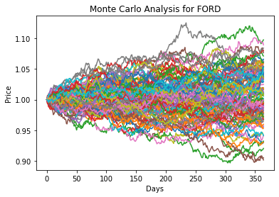

```python
days = 365
dt = 1/days
mu = rets.mean()['FORD']
sigma = rets.std()['FORD']

def stock_monte_carlo(start_price,days,mu,sigma):
    price = np.zeros(days)
    price[0] = start_price
    shock = np.zeros(days)
    drift = np.zeros(days)

    for x in range(1,days):
        shock[x] = np.random.normal(loc=mu * dt, scale=sigma * np.sqrt(dt))
        drift[x] = mu * dt
        price[x] = price[x-1] + (price[x-1] * (drift[x] + shock[x]))

    return price

FORD.head()

start_price=1.00

for run in range(100):
    plt.plot(stock_monte_carlo(start_price,days,mu,sigma))
plt.xlabel("Days")
plt.ylabel("Price")
plt.title('Monte Carlo Analysis for FORD')
```

**Runs Monte Carlo simulation 100 times**

**SET LARGER NUMBERS OF RUNS**

```python
runs = 10000

simulations = np.zeros(runs)

np.set_printoptions(threshold=5)

for run in range(runs):
    simulations[run] = stock_monte_carlo(start_price,days,mu,sigma)[days-1];
```

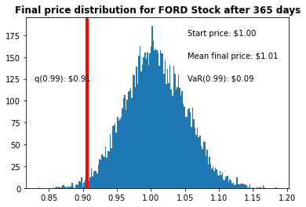

```python
q = np.percentile(simulations, 1)

plt.hist(simulations,bins=200)

plt.figtext(0.6, 0.8, s="Start price: $%.2f" %start_price)

plt.figtext(0.6, 0.7, "Mean final price: $%.2f" % simulations.mean())

plt.figtext(0.6, 0.6, "VaR(0.99): $%.2f" % (start_price - q,))

plt.figtext(0.15, 0.6, "q(0.99): $%.2f" % q)

plt.axvline(x=q, linewidth=4, color='r')

plt.title(u"Final price distribution for FORD Stock after %s days" % days, weight='bold');
```

**We get a histogram of the end results for a much larger run. Now we'lll define q as the 1% empirical qunatile, this basically means that 99% of the values should fall between here**

```python
VWAGY.head()
```

| Date | High | Low | Open | Close | Volume | Adj Close | Total Traded | Daily_return | Cumulative Return | MA10 | MA20 | MA50 |
| --- | --- | --- | --- | --- | --- | --- | --- | --- | --- | --- | --- | --- |
| 2020-01-02 | 19.896999 | 19.639999 | 19.667999 | 19.889999 | 71000.0 | 19.255404 | 1.396428e+06 | NaN | NaN | NaN | NaN | NaN |
| 2020-01-03 | 19.540001 | 19.378000 | 19.430000 | 19.410000 | 35500.0 | 18.790718 | 6.897650e+05 | -0.024133 | 0.975867 | NaN | NaN | NaN |
| 2020-01-06 | 19.650000 | 19.330000 | 19.360001 | 19.620001 | 115300.0 | 18.994019 | 2.232208e+06 | 0.010819 | 0.986425 | NaN | NaN | NaN |
| 2020-01-07 | 19.700001 | 19.459999 | 19.586000 | 19.520000 | 181300.0 | 18.897209 | 3.550942e+06 | -0.005097 | 0.981398 | NaN | NaN | NaN |
| 2020-01-08 | 19.690001 | 19.389999 | 19.400000 | 19.670000 | 232000.0 | 19.042423 | 4.500800e+06 | 0.007684 | 0.988939 | NaN | NaN | NaN |

**VW**

```python
days = 365

dt = 1/days

mu = rets.mean()['VWAGY']

sigma = rets.std()['VWAGY']

def stock_monte_carlo(start_price,days,mu,sigma):
    price = np.zeros(days)
    price[0] = start_price
    shock = np.zeros(days)
    drift = np.zeros(days)

    for x in range(1,days):
        shock[x] = np.random.normal(loc=mu * dt, scale=sigma * np.sqrt(dt))
        drift[x] = mu * dt
        price[x] = price[x-1] + (price[x-1] * (drift[x] + shock[x]))

    return price
```

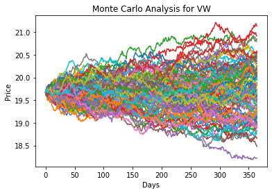

```python
start_price=19.67

for run in range(100):
    plt.plot(stock_monte_carlo(start_price,days,mu,sigma))
plt.xlabel("Days")
plt.ylabel("Price")
plt.title('Monte Carlo Analysis for VW')
```

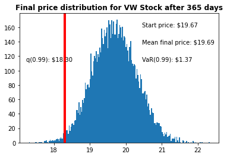

```python
runs = 10000
simulations = np.zeros(runs)
np.set_printoptions(threshold=5)

for run in range(runs):
    simulations[run] = stock_monte_carlo(start_price,days,mu,sigma)[days-1];

q = np.percentile(simulations, 1)
plt.hist(simulations,bins=200)
plt.figtext(0.6, 0.8, s="Start price: $%.2f" %start_price)
plt.figtext(0.6, 0.7, "Mean final price: $%.2f" % simulations.mean())
plt.figtext(0.6, 0.6, "VaR(0.99): $%.2f" % (start_price - q,))
plt.figtext(0.15, 0.6, "q(0.99): $%.2f" % q)
plt.axvline(x=q, linewidth=4, color='r')

plt.title(u"Final price distribution for VW Stock after %s days" % days, weight='bold');
```

**THE END**